# Matplotlib

`Matplotlib` là một thư viện dùng để vẽ đồ thị cơ bản trong Python, nó cho phép xuất hình ảnh ra các định dạng khác nhau như *jpeg, png*... Trong tài liệu này,chúng ta sẽ tìm hiểu các vẽ hình cơ bản với `Matplotlib`

## VẼ ĐỒ THỊ ĐƠN GIẢN

Trước hết, để sử dụng, cần phải tải gói thư viện `matplotlib.pyplot`.

```python
import numpy as np
import matplotlib.pyplot as plt
```

`Matplotlib` cung cấp nhiều kiểu hiển thị kết quả của hình vẽ. Trong ví dụ dưới đây, sử dụng định dạng hiển thị tên là `ggplot`, tuy nhiên bạn có thể lựa chọn các kiểu hiển khác nhau như ở đây [LINK](https://matplotlib.org/stable/gallery/style_sheets/style_sheets_reference.html)

```python
plt.style.use("ggplot")
```

Vẽ đồ thị nối các điểm với giá trị các tung độ lưu trong một list, giá trị hoành độ tương ứng với các chỉ số của list. Chúng ta sử dụng hàm `plot()` như dưới đây

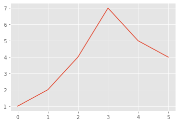

```python
plt.plot([1, 2, 4, 7, 5, 4])
plt.show()
```

Trường hợp này, sử dụng 2 list để lưu các giá trị hoành độ và tung độ của các điểm cần vẽ

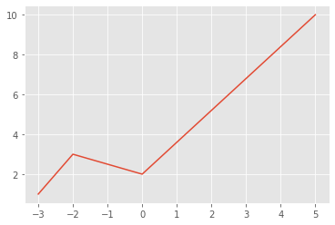

```python
plt.plot([-3, -2, 0, 5], [1, 3, 2, 10])
plt.show()
```

Sử dụng hàm `xlim` và `ylim` để thay đổi giá trị hiển thị đầu và cuối mỗi trục

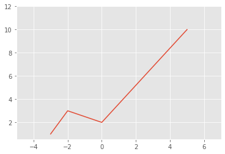

```python
plt.plot([-3, -2, 0, 5], [1, 3, 2, 10])
plt.xlim(-5, 7)
plt.ylim(None, 12)
plt.show()
```

Tương tự cách sử dụng hàm `plot()` như trên, ta thử vẽ đồ thị hàm y = x*x bằng cách khởi tạo list `x` có 500 giá trị cách đều nhau có giá trị từ -2 đến 2, và list `y` có giá trị là y = x*x. Ta vẽ đồ thị với màu xanh dương (màu sắc mặc định là màu đỏ)

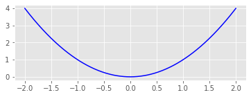

```python
x = np.linspace(-2, 2, 500)
y = x**2

plt.plot(x, y, color='blue')
plt.show()
```

Sử dụng các hàm `title()`, `xlabel()` và `ylabel()` để thêm tiêu đề cho hình vẽ và tiêu đề cho 2 trục x, y

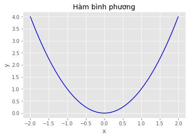

```python
plt.plot(x, y, color='blue')
plt.title('Hàm bình phương')
plt.xlabel('x')
plt.ylabel('y')
plt.grid(True)    #Thử thay đổi sang giá trị False để xem kết quả
plt.show()
```

## THAY ĐỔI KÍCH THƯỚC ĐỒ THỊ

Giả sử bạn muốn vẽ lại đồ thị trên với kích thước khác với kích thước mặc định. Bạn có thể dùng hàm `subplots(figsize=(...))` với tham số là kích thước theo đơn vị inch

Ví dụ: vẽ đồ thị với kích thước 12x4 (inches)

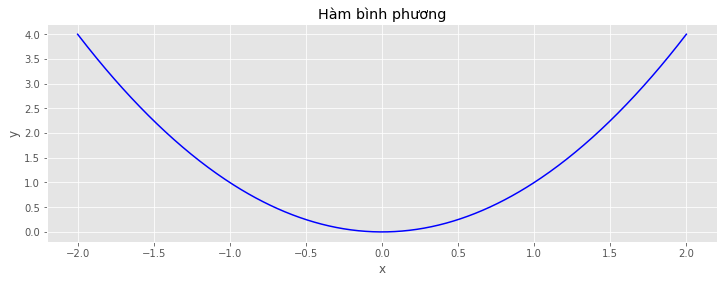

```python
plt.subplots(figsize=(12, 4))

plt.plot(x, y, color='blue')
plt.title('Hàm bình phương')
plt.xlabel('x')
plt.ylabel('y')
plt.grid(True)    #Thử thay đổi sang giá trị False để xem kết quả
plt.show()
```

## ĐỊNH DẠNG ĐƯỜNG THẲNG VÀ MÀU SẮC

Mặc định khi vẽ, matplotlib sẽ vẽ bằng cách nối các đường thẳng màu đỏ đến các điểm. Tuy nhiên, bạn có thể thêm vào tham số thứ ba để thay đổi màu sắc và dạng đường vẽ. Ví dụ: `'b--'` nghĩa là đường đứt nét màu xanh dương (blue dashed line)

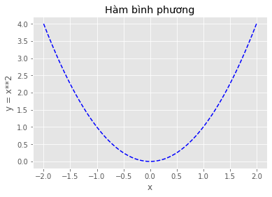

```python
plt.plot(x, y, 'b--')
plt.title('Hàm bình phương')
plt.xlabel('x')
plt.ylabel('y = x**2')

plt.show()
```

Sử dụng đường với các định dạng khác nhau, bạn có thể vẽ nhiều hình trên cùng một đồ thị

Để tham khảo danh sách các định dạng đường (line style) và màu sắc bạn có thể xem ở đây [(LINK)](https://matplotlib.org/2.0.2/api/pyplot_api.html)

Ngoài ra, với mỗi loại định dạng bạn cũng có thể thay đổi độ rộng, độ trong suốt hay định dạng đường nối. Chi tiết bạn có thể tham khảo ở đây [(LINK)](https://matplotlib.org/2.0.2/users/pyplot_tutorial.html)

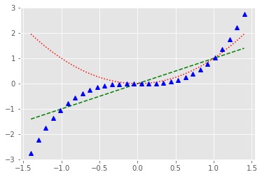

```python
x = np.linspace(-1.4, 1.4, 30)
plt.plot(x, x, 'g--')
plt.plot(x, x**2, 'r:')
plt.plot(x, x**3, 'b^')

plt.show()
```

## VẼ ĐỒ THỊ CON

Bạn có thể vẽ nhiều đồ thị con trong cùng một đồ thị lớn. Các đồ thị con được tổ chức dạng ma trận bằng các khai báo số dòng, số cột trong hàm `subplot()`. Tham số thứ 3 trong hàm `subplot()` thể hiện chỉ mục của đồ thị được đánh số từ 1 theo thứ tự từ trái sang phải, từ trên xuống dưới.

Chi tiết có thể tham khảo ở đây [(LINK)](https://matplotlib.org/2.0.2/users/gridspec.html)

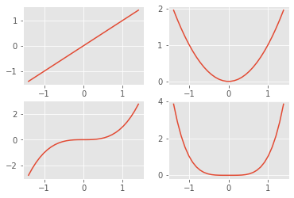

```python
x = np.linspace(-1.4, 1.4, 30)
plt.subplot(2, 2, 1)
plt.plot(x, x)         # ma trận đồ thị con 2 dòng, 2 cột, đồ thị thứ nhất trái trên

plt.subplot(2, 2, 2)
plt.plot(x, x**2)      # ma trận đồ thị con 2 dòng, 2 cột, đồ thị thứ hai phải trên

plt.subplot(2, 2, 3)   # ma trận đồ thị con 2 dòng, 2 cột, đồ thị thứ ba trái dưới
plt.plot(x, x**3)

plt.subplot(2, 2, 4)
plt.plot(x, x**4)      # ma trận đồ thị con 2 dòng, 2 cột, đồ thị thứ tư phải dưới

plt.show()
```

Cũng có thể mở rộng kích thước của đồ thị như ví dụ dưới đây

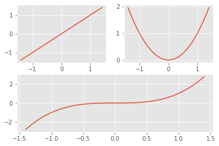

```python
plt.subplot(2, 2, 1)  # 2 rows, 2 columns, 1st subplot = top left
plt.plot(x, x)

plt.subplot(2, 2, 2)  # 2 rows, 2 columns, 2nd subplot = top right
plt.plot(x, x**2)

plt.subplot(2, 1, 2)  # 2 rows, *1* column, 2nd subplot = bottom
plt.plot(x, x**3)
plt.show();
```

## THÊM CHỮ VÀ CHÚ THÍCH

Bạn có thể thêm bất cứ chữ hay chú thích bằng cách sử dụng hàm `text()`, tham số cần truyền vào là toạ độ x, y và chuỗi cần thêm. Ngoài ra, các tham số khác cũng có thể thay đổi như ví dụ dưới đây như: màu sắc (color), căn lề ngang(horizontalalignment), góc xoay(rotation)...

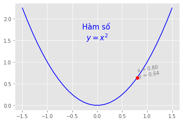

```python
x = np.linspace(-1.5, 1.5, 30)
px = 0.8
py = px**2

plt.plot(x, x**2, "b-", px, py, "ro")

plt.text(0, 1.5, "Hàm số \n$y = x^2$", fontsize=15, color='blue', horizontalalignment="center")
plt.text(px, py, "x = %0.2f\ny = %0.2f"%(px, py), rotation=10, color='gray')

plt.show()
```

## NHÃN VÀ GHI CHÚ

Bạn có thể thêm nhãn cho mỗi đồ thị vẽ từ hàm `plot()` bằng cách thêm tham số `label`. Sau đó, để hiển thị các nhãn của các đường bạn gọi hàm `legend()` với tham số loc `(location)` chỉ vị trí xuất hiện.

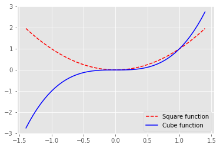

```python
x = np.linspace(-1.4, 1.4, 50)

plt.plot(x, x**2, "r--", label="Square function")
plt.plot(x, x**3, "b-", label="Cube function")

plt.legend(loc="lower right")
plt.show()
```